# Trabajo Práctico Nº1: Regresión lineal

Renso Gil y Leandro Morinigo

14/10/2022

## Carga de librerías y datasets

### Librerías a utiliza

Se cargan las librerías necesarias para el trabajo práctico. ###Librerias

```r
library(tidyverse)
library(tidymodels)
library(rsample)
library(ggplot2)
library(GGally)
```

### Cargar archivo

```r
datos_properati <- read.csv("properati_preprocesado_2022.csv")
glimpse(datos_properati)
```

```
Rows: 28,773
Columns: 9
$ id              <chr> "1ZHYJgyAbGUcX+v1Ggj1rA==", "BcAHh7UMLQpQ/axyyuwqkQ==", "LlmVTCwhFsqei54xoCbyLA==…
$ l3              <chr> "Palermo", "Caballito", "Flores", "Flores", "Retiro", "Almagro", "Palermo", "Pale…
$ rooms           <int> 1, 1, 1, 1, 1, 1, 1, 1, 1, 1, 1, 1, 1, 1, 1, 1, 1, 1, 1, 1, 1, 1, 1, 1, 1, 1, 1, …
$ bathrooms       <int> 1, 1, 1, 1, 1, 1, 1, 1, 1, 1, 1, 1, 1, 1, 1, 1, 1, 1, 1, 1, 1, 1, 1, 1, 1, 1, 1, …
$ surface_total   <int> 38, 55, 37, 37, 29, 41, 36, 31, 30, 36, 32, 34, 27, 30, 31, 40, 35, 37, 37, 37, 3…
$ surface_covered <int> 35, 36, 32, 33, 26, 38, 32, 29, 28, 33, 32, 27, 27, 30, 27, 36, 31, 33, 33, 33, 3…
$ price           <int> 125000, 74500, 79900, 53700, 57000, 99000, 93000, 68000, 84900, 65000, 62000, 667…
$ property_type   <chr> "Departamento", "Departamento", "Departamento", "Departamento", "Departamento", "…
$ precio_en_miles <int> 125, 74, 80, 54, 57, 99, 93, 68, 85, 65, 62, 67, 45, 58, 45, 78, 77, 53, 54, 54, …
```

## Correlación entre variables

[figure not shown]

[figure not shown]

```r
# graficamos con ggpairs coloreando por property type
g <- ggpairs(datos_properati %>% select(-c(id,l3)), aes(color = property_type),
          upper = list(continuous = wrap("cor", size = 3, hjust=0.5)), legend = 25, progress=FALSE) +
  theme(axis.text.x = element_text(angle = 90, hjust = 1), legend.position = "bottom") +
  theme_bw()
# hacemos un loop para cambiar los colores del gráfico
for(i in 1:g$nrow) {
  for(j in 1:g$ncol){
    g[i,j] <- g[i,j] +
      scale_fill_brewer(palette="Dark2") +
      scale_color_brewer(palette="Dark2")
        }
}
g
```

### Particionar el dataset en entrenamiento y test

```r
# fijamos semilla
set.seed(22)
# Partición Train y Test, indicando proporción
train_test <- initial_split(datos_properati, prop = 0.75)
train_data <- training(train_test)
test_data <- testing(train_test)
# vemos las dimensiones de cada partición
train_data %>%
  dim_desc()
```

```
[1] "[21,579 x 9]"
```

#### Nuevas variables

Variables creadas a partir de los metros cuadradas por barrio

```r
# Creamos una nueva variable  de precios por metro cuadrado
train_data = train_data %>%
  mutate(pxm2 = round(price/surface_total,0))
# Armamos un dataframe que muestre los promedios de pxm2 en cada barrio
AVG_pxm2_l3 = train_data %>%
  group_by(l3) %>%
  summarise(AVG_pxm2_l3 = mean(pxm2))
AVG_pxm2_l3
```

| l3 | AVG_pxm2_l3 |
| --- | --- |
| Abasto | 1806.935 |
| Agronomía | 1693.333 |
| Almagro | 1917.168 |
| Balvanera | 1637.851 |
| Barracas | 1767.963 |
| Barrio Norte | 2397.368 |
| Belgrano | 2720.808 |
| Boca | 1312.351 |
| Boedo | 1709.788 |
| Caballito | 2120.273 |

[output cut: 45 more lines]

Distribución del precio promedio por m2

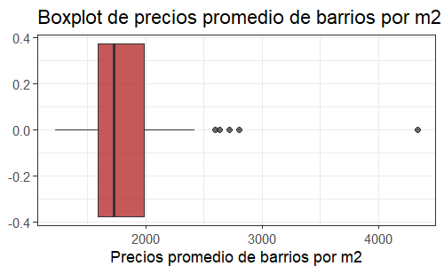

```r
# boxplot de precios por metro cuadrado
ggplot(data = AVG_pxm2_l3, aes(x = AVG_pxm2_l3)) +
  geom_boxplot(alpha = 0.75, fill="firebrick") +
  labs(title = "Boxplot de precios promedio de barrios por m2") +
  labs(x = "Precios promedio de barrios por m2") +
  theme_bw()
```

Aplicaremos el siguiente criterio para agrupar los barrios en:

- precio_bajo: barrios cuyo precio promedio por m2 sea menor al Q1
- precio_medio: barrios cuyo precio promedio se encuentre en el RI
- precio_alto: barrios cuyo precio promedio por m2 sea mayor al Q3

```r
# armamos nueva variable siguiendo tales criterios
AVG_pxm2_l3 = AVG_pxm2_l3 %>%
  mutate(tipo_barrio = case_when(
    AVG_pxm2_l3 < quantile(AVG_pxm2_l3)[2] ~ "precio_bajo",
    AVG_pxm2_l3 >= quantile(AVG_pxm2_l3)[2] & AVG_pxm2_l3 < quantile(AVG_pxm2_l3)[4] ~ "precio_medio",
    TRUE ~ "precio_alto"
                                 )
         )
write.csv(AVG_pxm2_l3, 'AVG_pxm2_l3.csv')

# unimos esta clasificación al dataset original
train_data = train_data %>% left_join(AVG_pxm2_l3, by = 'l3')
head(train_data)
```

|  | id | l3 | rooms | bathrooms | surface_total | surface_covered | price | property_type | precio_en_miles | pxm2 | AVG_pxm2_l3 | tipo_barrio |
| --- | --- | --- | --- | --- | --- | --- | --- | --- | --- | --- | --- | --- |
| 1 | 3ZTRccuKkerzZacwEqu5Ww== | Villa Crespo | 2 | 1 | 35 | 35 | 71900 | Departamento | 72 | 2054 | 2040.435 | precio_alto |
| 2 | w4CylJDnRV1LDPVFUDhQ6Q== | Monte Castro | 2 | 1 | 59 | 47 | 106000 | Departamento | 106 | 1797 | 1616.358 | precio_medio |
| 3 | LCr4E+OxYd0aJcUojaq0VA== | Barrio Norte | 5 | 2 | 150 | 140 | 298000 | Departamento | 298 | 1987 | 2397.368 | precio_alto |
| 4 | DU+IWE3DfhcZjC8GFpw3jA== | Villa Ortuzar | 1 | 1 | 37 | 33 | 82000 | Departamento | 82 | 2216 | 1802.859 | precio_medio |
| 5 | ZYIwIc0VZw4a0TDOrc1n5Q== | Caballito | 2 | 1 | 75 | 38 | 105000 | Departamento | 105 | 1400 | 2120.273 | precio_alto |
| 6 | 4n/2IpbZxISCn8cXpiL+FA== | Colegiales | 2 | 1 | 34 | 34 | 62000 | Departamento | 62 | 1824 | 2313.995 | precio_alto |

### Modelo de regresión multiple

$E(precio)=\beta_0+\beta_1surface\_covered+\beta_2tipo\_barrio$

```r
# Modelo ultiple
modelo_sc_tb <- lm(price ~ surface_covered + tipo_barrio, data = train_data)
tidy_sc_tb <- tidy(modelo_sc_tb, conf.int = TRUE)
tidy_sc_tb
```

| term | estimate | std.error | statistic | p.value | conf.low | conf.high |
| --- | --- | --- | --- | --- | --- | --- |
| (Intercept) | 7435.986 | 1389.52824 | 5.351446 | 8.814400e-08 | 4712.408 | 10159.564 |
| surface_covered | 2862.753 | 12.52001 | 228.654187 | 0.000000e+00 | 2838.213 | 2887.293 |
| tipo_barrioprecio_bajo | -99441.545 | 3280.14879 | -30.316169 | 9.752626e-198 | -105870.879 | -93012.211 |
| tipo_barrioprecio_medio | -66924.423 | 1751.00134 | -38.220658 | 2.503125e-309 | -70356.515 | -63492.331 |

#### Significado de los coeficientes estimados

- $\hat{\beta_o}$ : (categoría basal de la variable categórica): es la media del precio para los barrios de precio alto sin superficie.
- $\hat{\beta_{surface\_covered}}$ : es la pendiente de incremento de precio por superficie para cada tipo de barrio.
- $\hat{\beta_{tipo\_barrioprecio\_bajo}}$ : es la diferencia en los niveles medios de precios de los barrios de precio bajos respecto de los barrios de precio alto (categoría basal)
- $\hat{\beta_{tipo\_barrioprecio\_medio}}$ : es la diferencia en los niveles medios de precios de los barrios de precio medios respecto de los barrios de precio alto (categoría basal)